# Is There a Gender Pay Gap?

Replication code for the 2025-26 UK gender pay gap data

Deyu Wang (5796695)

12 十月 2026

```r
library(tidyverse)   # dplyr, ggplot2, readr, ...
library(lubridate)   # date handling for the stretch task
library(scales)      # nice axis labels
library(knitr)       # kable() for tables
```

```r
# Formatting helpers, so I can quote numbers inline instead of typing them out.

# p value in APA format
fmt_p <- function(p) {
  if (p < .001) "< .001" else paste0("= ", sub("^0", "", sprintf("%.3f", p)))
}

# Round to 2 dp, no scientific notation
r2 <- function(x) formatC(x, format = "f", digits = 2)
```

# 1 The data

The data are the full set of employer returns to the UK Government’s [gender pay gap service](https://gender-pay-gap.service.gov.uk/viewing/download-data/2025) for the 2025-26 reporting year. Every UK employer with 250 or more employees must report, so this is close to a census of large employers rather than a sample of them.

```r
pay.gap <- read_csv("UK_gender_pay_gap_2025-26.csv")

pay.gap
```

```
## # A tibble: 11,187 × 27
##    EmployerName               EmployerId Address PostCode CompanyNumber SicCodes
##    <chr>                           <dbl> <chr>   <chr>    <chr>         <chr>
##  1 "'PRIFYSGOL ABERYSTWYTH' …      19070 Aberys… SY23 3FL RC000641       <NA>
##  2 "\"RED BAND\" CHEMICAL CO…      16879 19 Smi… EH6 8NU  SC016876      "47730"
##  3 "10 TRINITY SQUARE HOTEL …      19455 5 Mark… SE1 3TQ  08064685      "82990"
##  4 "1509 GROUP"                    15320 Royal … GU1 3BB  04104101      "85200,…
##  5 "1LIFE MANAGEMENT SOLUTIO…        687 The St… PR7 4AT  02566586      "93110,…
##  6 "1ST HOME CARE LTD."            17484 Suite … G32 9AT  SC272838      "86900,…
##  7 "1ST LOCATE (UK) LIMITED"       46212 Apson … LS15 9JN 03702599      "63110,…
##  8 "2 AGRICULTURE GROWING LI…       6290 2nd Fl… B3 2BJ   05969169      "1470"
##  9 "2 AGRICULTURE LIMITED"         14399 Fairvi… EH28 8NB SC156515      "1470,\…
## 10 "2 EXCEL (HOLDINGS) LIMIT…      21894 72 Fie… W4 1DB   10656583      "64209"
## # ℹ 11,177 more rows
## # ℹ 21 more variables: DiffMeanHourlyPercent <dbl>,
## #   DiffMedianHourlyPercent <dbl>, DiffMeanBonusPercent <dbl>,
## #   DiffMedianBonusPercent <dbl>, MaleBonusPercent <dbl>,
## #   FemaleBonusPercent <dbl>, MaleLowerQuartile <dbl>,
## #   FemaleLowerQuartile <dbl>, MaleLowerMiddleQuartile <dbl>,
## #   FemaleLowerMiddleQuartile <dbl>, MaleUpperMiddleQuartile <dbl>, …
```

```r
n.employers <- nrow(pay.gap)
n.variables <- ncol(pay.gap)
```

The file contains 11,187 employers and 27 variables.

# 2 Data dictionary

My understanding of what each variable actually is. The pay gap variables are all *percentages of the male figure*, so a **positive** number means women are paid **less** than men.

**Table 1.** Data dictionary for `UK_gender_pay_gap_2025-26.csv`.

| Variable | Type | What I think it is |
| --- | --- | --- |
| `EmployerName` | character | Name of the reporting employer, as submitted |
| `EmployerId` | numeric | Identifier for the employer on the pay gap service |
| `Address` | character | Registered address of the employer |
| `PostCode` | character | Postcode of that address |
| `CompanyNumber` | character | Companies House registration number; blank for some public bodies |
| `SicCodes` | character | Standard Industrial Classification code(s) for what the employer does; several codes can appear in one cell |
| `DiffMeanHourlyPercent` | numeric | **Outcome of interest.** (male mean - female mean) / male mean x 100 for hourly pay. A value of 10 means women earn 10% less per hour on average |
| `DiffMedianHourlyPercent` | numeric | The same calculation on the *median* hourly rate |
| `DiffMeanBonusPercent` | numeric | The same calculation on *mean* bonus pay; missing where no bonuses were paid |
| `DiffMedianBonusPercent` | numeric | The same calculation on *median* bonus pay |
| `MaleBonusPercent` | numeric | Percentage of male employees who received a bonus |
| `FemaleBonusPercent` | numeric | Percentage of female employees who received a bonus |
| `MaleLowerQuartile` | numeric | Percentage of the lowest-paid quarter of employees who are men |
| `FemaleLowerQuartile` | numeric | Percentage of the lowest-paid quarter who are women |
| `MaleLowerMiddleQuartile` | numeric | Percentage of the second-lowest-paid quarter who are men |
| `FemaleLowerMiddleQuartile` | numeric | Percentage of the second-lowest-paid quarter who are women |
| `MaleUpperMiddleQuartile` | numeric | Percentage of the second-highest-paid quarter who are men |
| `FemaleUpperMiddleQuartile` | numeric | Percentage of the second-highest-paid quarter who are women |
| `MaleTopQuartile` | numeric | Percentage of the highest-paid quarter who are men |
| `FemaleTopQuartile` | numeric | Percentage of the highest-paid quarter who are women |
| `CompanyLinkToGPGInfo` | character | URL where the employer published its own commentary on the figures |
| `ResponsiblePerson` | character | Name and job title of the person signing off the return |
| `EmployerSize` | character | Banded headcount, e.g. “250 to 499”, “1000 to 4999”; a label, not a number |
| `CurrentName` | character | Current name of the employer, which can differ from `EmployerName` after a rename |
| `SubmittedAfterTheDeadline` | logical | Whether the return arrived after the employer’s due date |
| `DueDate` | datetime | Reporting deadline: 31 March 2026 for public sector employers, 5 April 2026 for businesses and charities. Used to derive sector below |
| `DateSubmitted` | datetime | When the return was actually submitted |

# 3 The mean gender pay gap

```r
gap.summary <- pay.gap %>%
  summarise(
    n = n(),
    missing = sum(is.na(DiffMeanHourlyPercent)),
    mean = mean(DiffMeanHourlyPercent),
    sd = sd(DiffMeanHourlyPercent),
    median = median(DiffMeanHourlyPercent),
    min = min(DiffMeanHourlyPercent),
    max = max(DiffMeanHourlyPercent)
  )

gap.summary %>%
  kable(digits = 2,
        caption = "Table 2. Mean hourly gender pay gap across UK employers (%).")
```

Table 2. Mean hourly gender pay gap across UK employers (%).

| n | missing | mean | sd | median | min | max |
| --- | --- | --- | --- | --- | --- | --- |
| 11187 | 0 | 11.5 | 15.99 | 10.64 | -757 | 100 |

```r
mean.gap <- gap.summary$mean
sd.gap <- gap.summary$sd
median.gap <- gap.summary$median

# How one-sided is the distribution?
pct.favour.men <- mean(pay.gap$DiffMeanHourlyPercent > 0) * 100
pct.favour.women <- mean(pay.gap$DiffMeanHourlyPercent < 0) * 100
```

Across the 11,187 employers the mean hourly pay gap is **11.50%** (*SD* = 15.99, median = 10.64%). At 85.01% of employers women are paid less per hour on average than men, against 14.43% where they are paid more.

# 4 Figure

```r
# How many employers fall outside the plotted range?
n.clipped <- sum(pay.gap$DiffMeanHourlyPercent < -40 |
                 pay.gap$DiffMeanHourlyPercent > 60)

n.clipped
```

```
## [1] 99
```

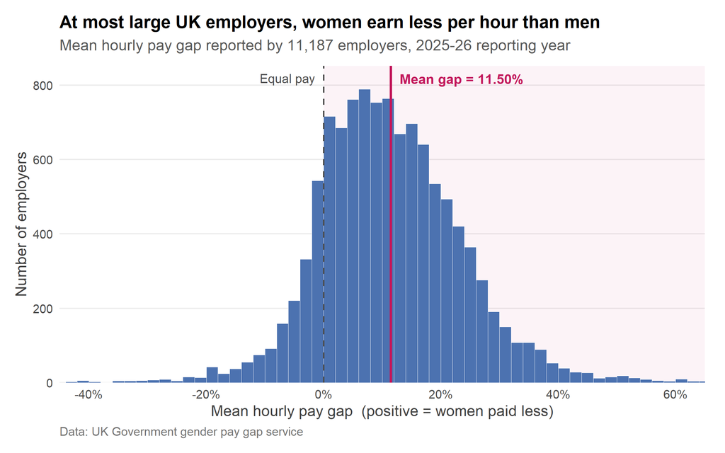

```r
ggplot(pay.gap, aes(x = DiffMeanHourlyPercent)) +
  # shade the half of the scale on which women are worse off
  annotate("rect",
           xmin = 0, xmax = Inf, ymin = 0, ymax = Inf,
           fill = "#C2185B", alpha = 0.05) +
  geom_histogram(binwidth = 2, boundary = 0,
                 fill = "#4C72B0", colour = "white", linewidth = 0.2) +
  geom_vline(xintercept = 0, linetype = "dashed",
             colour = "grey30", linewidth = 0.6) +
  geom_vline(xintercept = mean.gap,
             colour = "#C2185B", linewidth = 0.9) +
  annotate("text", x = mean.gap + 1.5, y = Inf,
           label = paste0("Mean gap = ", r2(mean.gap), "%"),
           hjust = 0, vjust = 1.8, colour = "#C2185B",
           fontface = "bold", size = 3.8) +
  annotate("text", x = -1.5, y = Inf, label = "Equal pay",
           hjust = 1, vjust = 1.8, colour = "grey30", size = 3.5) +
  coord_cartesian(xlim = c(-40, 60)) +
  scale_x_continuous(breaks = seq(-40, 60, 20),
                     labels = function(x) paste0(x, "%")) +
  scale_y_continuous(labels = comma, expand = expansion(mult = c(0, 0.08))) +
  labs(
    title = "At most large UK employers, women earn less per hour than men",
    subtitle = "Mean hourly pay gap reported by 11,187 employers, 2025-26 reporting year",
    x = "Mean hourly pay gap  (positive = women paid less)",
    y = "Number of employers",
    caption = "Data: UK Government gender pay gap service"
  ) +
  theme_minimal(base_size = 12) +
  theme(
    plot.title = element_text(face = "bold", size = 14),
    plot.subtitle = element_text(colour = "grey35", margin = margin(b = 10)),
    plot.caption = element_text(colour = "grey45", hjust = 0),
    panel.grid.minor = element_blank(),
    panel.grid.major.x = element_blank(),
    axis.title = element_text(colour = "grey25"),
    plot.margin = margin(12, 16, 12, 12)
  )
```

# 5 What hypothesis is the *t*-test testing?

The unit of analysis is the **employer**, not the employee. Each employer contributes exactly one number: its own mean hourly pay gap, in percent.

- **Null hypothesis.** In the population of large UK employers the mean of the employer-level hourly pay gap is zero. Employers may deviate from parity in either direction, but on average men’s and women’s mean hourly pay is the same.
- **Alternative hypothesis.** The population mean of the employer-level pay gap is not zero. This is two-tailed: the direction was not fixed in advance.

A one-sample *t*-test is the right test because there is a single sample of employer-level values and a theoretically meaningful comparison value of zero, which is exactly parity. The test asks how far the observed mean sits from zero in units of the standard error of the mean, and the *t* distribution with *n* - 1 degrees of freedom gives the probability of a difference at least this large if the null hypothesis were true.

The test assumes that observations are independent, which holds because there is one return per employer, and that the sampling distribution of the mean is approximately normal. The raw distribution in Figure 1 is heavy-tailed rather than normal, but with *n* = 11,187 the central limit theorem makes the test robust to that.

# 6 The *t*-test

```r
gap.test <- t.test(pay.gap$DiffMeanHourlyPercent, mu = 0)

gap.test
```

```
##
##  One Sample t-test
##
## data:  pay.gap$DiffMeanHourlyPercent
## t = 76.057, df = 11186, p-value < 2.2e-16
## alternative hypothesis: true mean is not equal to 0
## 95 percent confidence interval:
##  11.20471 11.79754
## sample estimates:
## mean of x
##  11.50112
```

```r
t1 <- gap.test$statistic
df1 <- gap.test$parameter
p1 <- gap.test$p.value
ci1 <- gap.test$conf.int
d1 <- mean.gap / sd.gap   # Cohen's d for a one-sample test
```

# 7 What the test tells us

Women at large UK employers were paid significantly less per hour than men. The mean hourly pay gap across employers was 11.50% in women’s disfavour (*SD* = 15.99), reliably greater than the 0% that equal pay would produce, *t*(11186) = 76.06, *p* < .001, 95% CI [11.20, 11.80], *d* = 0.72. Put another way, a typical large UK employer pays women about 11 to 12 pence less for every pound it pays men. So I reject the null hypothesis.

# 8 Stretch task: public sector versus business and charity

Public sector employers had to report by 31 March 2026, businesses and charities by 5 April 2026, so `DueDate` identifies the sector.

```r
pay.gap <- pay.gap %>%
  mutate(
    DueDate = ymd_hms(DueDate),
    Sector = ifelse(DueDate == ymd("2026-03-31"),
                    "Public Sector", "Business / Charity")
  )

sector.summary <- pay.gap %>%
  group_by(Sector) %>%
  summarise(
    n = n(),
    mean = mean(DiffMeanHourlyPercent),
    sd = sd(DiffMeanHourlyPercent),
    median = median(DiffMeanHourlyPercent),
    IQR = IQR(DiffMeanHourlyPercent),
    pct.favour.women = mean(DiffMeanHourlyPercent < 0) * 100,
    .groups = "drop"
  )

sector.summary %>%
  kable(digits = 2,
        caption = "Table 3. Mean hourly gender pay gap by sector (%).")
```

Table 3. Mean hourly gender pay gap by sector (%).

| Sector | n | mean | sd | median | IQR | pct.favour.women |
| --- | --- | --- | --- | --- | --- | --- |
| Business / Charity | 9242 | 11.11 | 16.91 | 10.1 | 15.81 | 15.76 |
| Public Sector | 1945 | 13.35 | 10.42 | 13.2 | 14.40 | 8.07 |

```r
mean.pub <- sector.summary$mean[sector.summary$Sector == "Public Sector"]
mean.biz <- sector.summary$mean[sector.summary$Sector == "Business / Charity"]
sd.pub <- sector.summary$sd[sector.summary$Sector == "Public Sector"]
sd.biz <- sector.summary$sd[sector.summary$Sector == "Business / Charity"]
n.pub <- sector.summary$n[sector.summary$Sector == "Public Sector"]
n.biz <- sector.summary$n[sector.summary$Sector == "Business / Charity"]
iqr.pub <- sector.summary$IQR[sector.summary$Sector == "Public Sector"]
iqr.biz <- sector.summary$IQR[sector.summary$Sector == "Business / Charity"]
neg.pub <- sector.summary$pct.favour.women[sector.summary$Sector == "Public Sector"]
neg.biz <- sector.summary$pct.favour.women[sector.summary$Sector == "Business / Charity"]
```

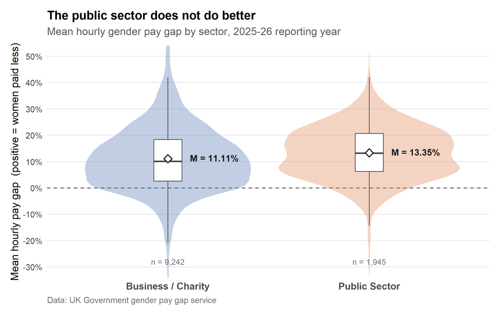

**Figure 2.** Mean hourly gender pay gap by sector. Violins show the shape of each distribution, boxes the median and interquartile range, and the white diamonds the sector means with 95% confidence intervals. Public sector employers report a slightly larger average gap than businesses and charities, and fewer of them sit below the parity line. The y axis is clipped at -30% and +50% for legibility; all observations are retained in the analysis.

```r
ggplot(pay.gap, aes(x = Sector, y = DiffMeanHourlyPercent, fill = Sector)) +
  geom_hline(yintercept = 0, linetype = "dashed", colour = "grey30") +
  geom_violin(alpha = 0.35, colour = NA, width = 0.9) +
  geom_boxplot(width = 0.14, outlier.shape = NA,
               fill = "white", colour = "grey25", linewidth = 0.4) +
  stat_summary(fun.data = mean_cl_normal, geom = "pointrange",
               shape = 23, size = 0.7, fill = "white",
               colour = "grey10", linewidth = 0.8) +
  geom_text(data = sector.summary,
            aes(x = Sector, y = mean,
                label = paste0("M = ", r2(mean), "%")),
            inherit.aes = FALSE,
            hjust = -0.45, vjust = 0.4, fontface = "bold",
            colour = "grey10", size = 3.6) +
  geom_text(data = sector.summary,
            aes(x = Sector, y = -30, label = paste0("n = ", comma(n))),
            inherit.aes = FALSE,
            vjust = -0.4, colour = "grey45", size = 3.2) +
  coord_cartesian(ylim = c(-30, 50)) +
  scale_y_continuous(breaks = seq(-30, 50, 10),
                     labels = function(x) paste0(x, "%")) +
  scale_fill_manual(values = c("Business / Charity" = "#4C72B0",
                               "Public Sector" = "#DD8452")) +
  labs(
    title = "The public sector does not do better",
    subtitle = "Mean hourly gender pay gap by sector, 2025-26 reporting year",
    x = NULL,
    y = "Mean hourly pay gap  (positive = women paid less)",
    caption = "Data: UK Government gender pay gap service"
  ) +
  theme_minimal(base_size = 12) +
  theme(
    legend.position = "none",
    plot.title = element_text(face = "bold", size = 14),
    plot.subtitle = element_text(colour = "grey35", margin = margin(b = 10)),
    plot.caption = element_text(colour = "grey45", hjust = 0),
    panel.grid.minor = element_blank(),
    panel.grid.major.x = element_blank(),
    axis.text.x = element_text(face = "bold", size = 11),
    plot.margin = margin(12, 16, 12, 12)
  )
```

```r
sector.test <- t.test(DiffMeanHourlyPercent ~ Sector, data = pay.gap)

sector.test
```

```
##
##  Welch Two Sample t-test
##
## data:  DiffMeanHourlyPercent by Sector
## t = -7.5805, df = 4413.1, p-value = 4.171e-14
## alternative hypothesis: true difference in means between group Business / Charity and group Public Sector is not equal to 0
## 95 percent confidence interval:
##  -2.809696 -1.655011
## sample estimates:
## mean in group Business / Charity      mean in group Public Sector
##                         11.11300                         13.34536
```

```r
t2 <- sector.test$statistic
df2 <- sector.test$parameter
p2 <- sector.test$p.value
ci2 <- sector.test$conf.int   # Business / Charity minus Public Sector

# Pooled SD, for an effect size on the difference
s.pooled <- sqrt(((n.biz - 1) * sd.biz^2 + (n.pub - 1) * sd.pub^2) /
                 (n.biz + n.pub - 2))
d2 <- (mean.pub - mean.biz) / s.pooled
```

Contrary to what you might expect, public sector employers reported a *significantly larger* mean hourly pay gap (*M* = 13.35%, *SD* = 10.42, *n* = 1,945) than businesses and charities (*M* = 11.11%, *SD* = 16.91, *n* = 9,242), a difference of 2.23 percentage points, Welch’s *t*(4413.10) = 7.58, *p* < .001, 95% CI [1.66, 2.81], *d* = 0.14.

I used Welch’s version because the variances are unequal (*SD* = 16.91 against 10.42). That gap in the standard deviations is misleading on its own, though. It comes from a few extreme business and charity returns, including the minimum of -757.00%, not from a generally wider spread: the interquartile ranges are close to identical (15.81 against 14.40 percentage points). The real difference is how consistently the gap runs against women. It favours women at 15.76% of businesses and charities, but at only 8.07% of public sector employers.

Since *d* = 0.14 is small, I would not say the public sector is much worse. The answer to the question is just that it is not better.

# 9 Caveats

- The unit is the employer, so every employer counts equally whether it has 250 staff or 250,000. This is the mean of employer gaps, not the gap facing the average UK worker.
- The gap is a raw difference in average hourly pay. It is not a measure of equal pay for equal work: it mixes pay discrimination together with occupational segregation, that is, who holds the senior and the junior jobs.
- The figures are self-reported by employers, and only employers with 250 or more staff must report, so smaller employers are absent entirely.
- 99 employers fall outside the plotted range of Figure 1, including one extreme value of -757.00%. All of them are retained in every calculation; no observation was excluded.